# Prob 5 CP3 Regressão Logística

October 15, 2016

```r
require(GGally)
library(ggplot2)
library(pscl)
library(stargazer)
library(dplyr, warn.conflicts = FALSE)
library(broom)
library(modelr)
theme_set(theme_bw())
dados <- read.csv("speedDating2.csv")
```

## Os dados

Temos dados descrevendo 5000 encontros relâmpagos de 4 minutos envolvendo 310 jovens americanos. Os dados originais foram coletados por professores da Columbia Business School. Aqui estamos usando uma versão com menos colunas para agilizar para vocês.

Os participantes tinham vários encontros de 4 minutos por noite. Após cada um, preenchiam fichas avaliando aqueles com quem se encontraram. Cada linha nos dados representa um desses encontros. Agora estaremos tentando explicar uma variável categórica, em busca dos fatores que têm mais efeito significativo na mesma, ela diz se houve match entre as duas pessoas no encontro.

## Pergunta 1

#### Que fatores nos dados têm efeito significativo na chance do casal ter um match? E como é esse efeito (positivo/negativo)?

Como há muitos fatores veremos cada um dos seguintes fatores separadamente, pois acredito que estes são os mais importantes. attr - nota para o quão atraente a outra pessoa foi avaliada fun - nota para o quão divertida a outra pessoa foi avaliada like - nota para o quanto a outra pessoa agradou no geral prob - nota para quanto se acha que a outra pessoa tem interesse em um reencontro shar - nota para quanto interesses são compartilhado com a outra pessoa sinc - nota para o quão sincera a outra pessoa foi avaliada Vamos ver cada variável separadamente. E o modelo tenta explicar a probabilidade de ocorrer o match.

##### Atração

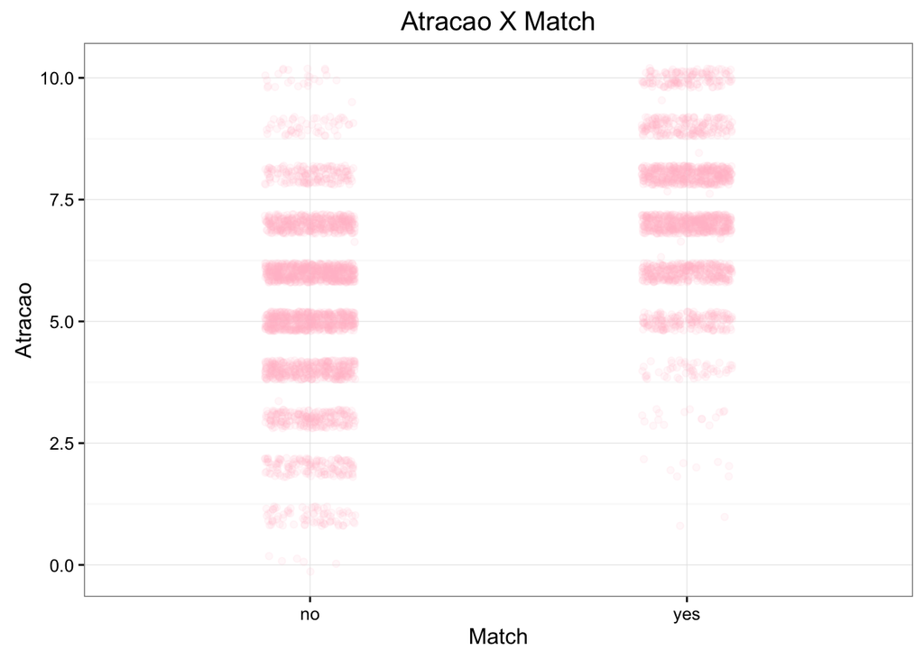

```r
ggplot(dados, aes(dados$dec, dados$attr)) +
  geom_point(alpha = 0.1, position = position_jitter(width = 0.3), color="pink") +
    labs(title="Atracao X Match", x= "Match", y="Atracao")
```

```r
bm <- glm(dec ~ attr,
          data = dados,
          family = "binomial")
tidy(bm, conf.int = TRUE, exponentiate = TRUE)
```

```
##          term   estimate  std.error statistic       p.value    conf.low
## 1 (Intercept) 0.01023838 0.15234034 -30.07484 1.033826e-198 0.007563984
## 2        attr 1.98121529 0.02321578  29.45025 1.249813e-190 1.894211276
##    conf.high
## 1 0.01374513
## 2 2.07471950
```

Como podemos ver atração tem uma correlação positiva, pelo gráfico vemos que quase não há sim quando os níveis de atração estão baixos. E como na regressão logistica o intervalo de confiança é > 1, confirma a correlação positiva.

##### Engraçado

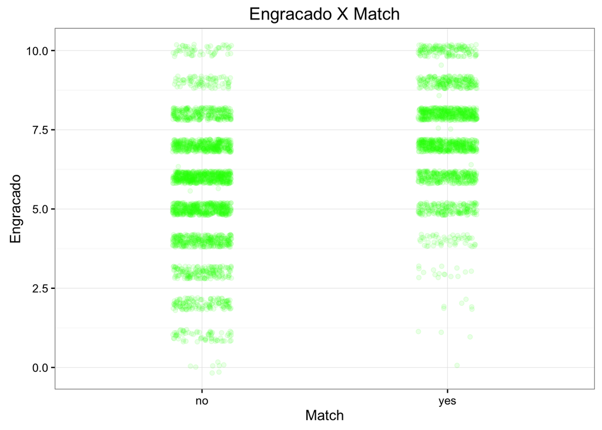

```r
ggplot(dados, aes(dados$dec, dados$fun)) +
  geom_point(alpha = 0.1, position = position_jitter(width = 0.3), color="green") +
    labs(title="Engracado X Match", x= "Match", y="Engracado")
```

```r
bm <- glm(dec ~ fun,
          data = dados,
          family = "binomial")
tidy(bm, conf.int = TRUE, exponentiate = TRUE)
```

```
##          term   estimate  std.error statistic       p.value   conf.low
## 1 (Intercept) 0.02597347 0.13745854 -26.55841 2.053676e-155 0.01977349
## 2         fun 1.67747715 0.02021356  25.59128 1.907703e-144 1.61303362
##    conf.high
## 1 0.03389448
## 2 1.74606587
```

Como podemos ver atração tem uma correlação positiva, pelo gráfico vemos que quase não há sim quando os níveis de atração estão baixos. Mas quando o nível de “Engraçadisse” é mais alto não há uniformidade, então só essa variável não é suficiente para o modelo. Na regressão logística o intervalo de confiança da variável fun é >1, confirmando a correlação positiva.

##### Gostou

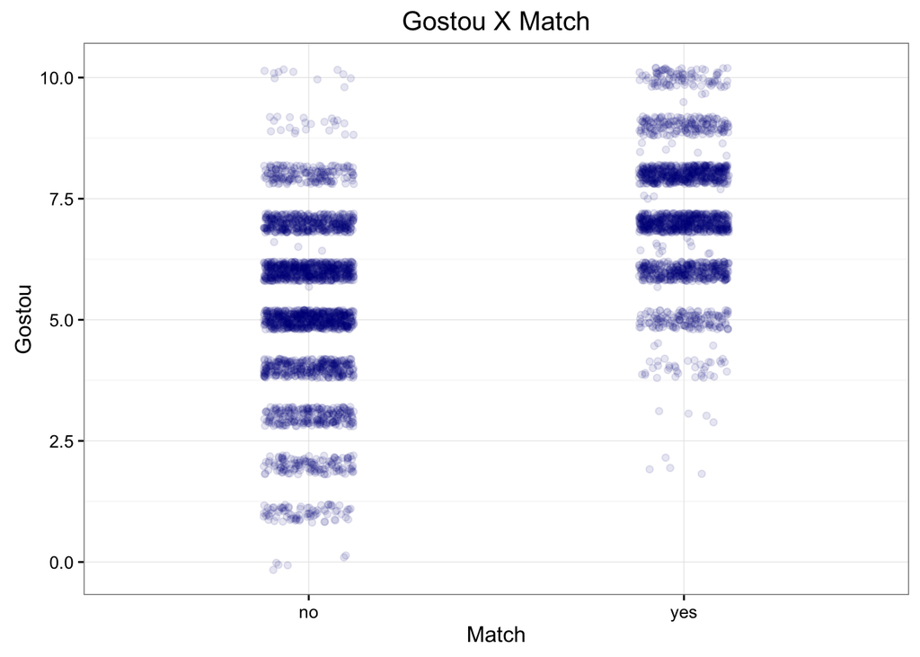

```r
ggplot(dados, aes(dados$dec, dados$like)) +
  geom_point(alpha = 0.1, position = position_jitter(width = 0.3), color="darkblue") +
    labs(title="Gostou X Match", x= "Match", y="Gostou")
```

```r
bm <- glm(dec ~ like,
          data = dados,
          family = "binomial")
tidy(bm, conf.int = TRUE, exponentiate = TRUE)
```

```
##          term    estimate  std.error statistic       p.value    conf.low
## 1 (Intercept) 0.003118727 0.18405342 -31.35139 9.313939e-216 0.002162399
## 2        like 2.389607064 0.02807552  31.02806 2.255633e-211 2.263456815
##     conf.high
## 1 0.004449543
## 2 2.526826447
```

Nessa a correlação é mais positiva ainda, o intervalo de confiança na regressão logística apresenta os maiores valores. Então se uma pessoa do casal gostou da outra existe maior chance dar outra pessoa também gostar, visto que quando um gosta muito existe poucos que não dão match.

##### Interesse em novo encontro

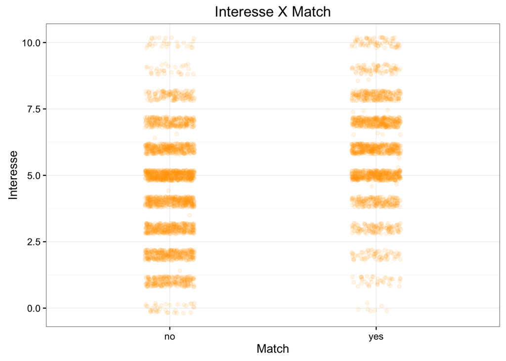

```r
ggplot(dados, aes(dados$dec, dados$prob)) +
  geom_point(alpha = 0.1, position = position_jitter(width = 0.3), color="orange") +
    labs(title="Interesse X Match", x= "Match", y="Interesse")
```

```r
bm <- glm(dec ~ prob,
          data = dados,
          family = "binomial")
tidy(bm, conf.int = TRUE, exponentiate = TRUE)
```

```
##          term  estimate  std.error statistic       p.value  conf.low
## 1 (Intercept) 0.1303655 0.08845310 -23.03383 2.136516e-117 0.1094352
## 2        prob 1.4023191 0.01581876  21.37509 2.278786e-101 1.3598552
##   conf.high
## 1 0.1547987
## 2 1.4468631
```

##### Interesses compartilhados

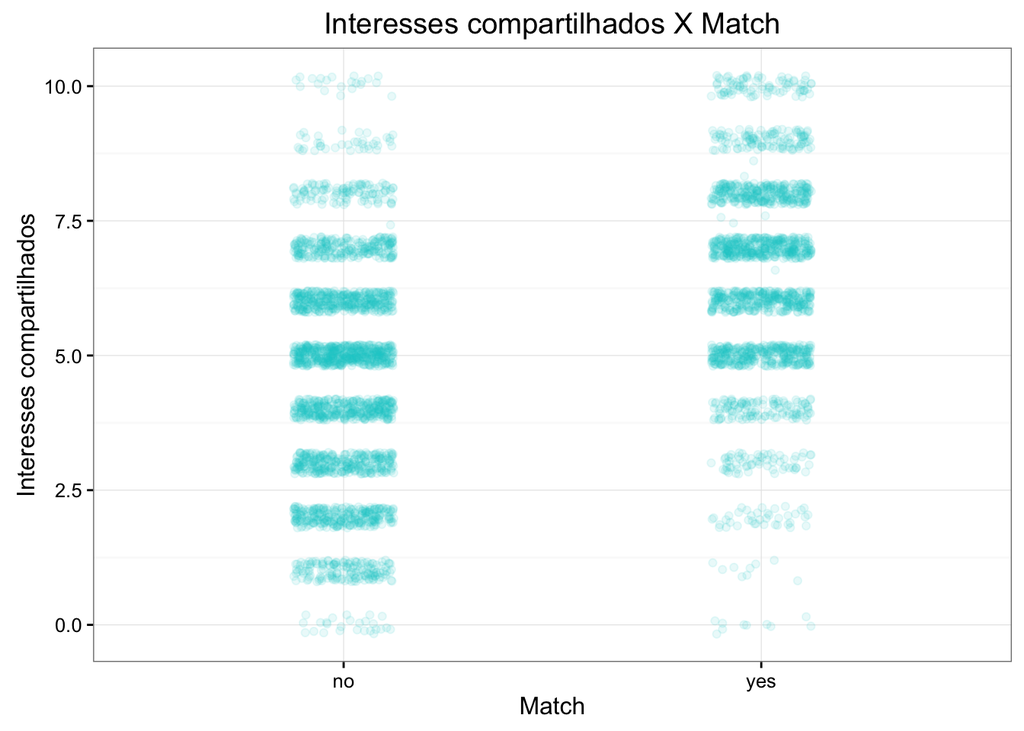

```r
ggplot(dados, aes(dados$dec, dados$shar)) +
  geom_point(alpha = 0.1, position = position_jitter(width = 0.3), color="cyan3") +
    labs(title="Interesses compartilhados X Match", x= "Match", y="Interesses compartilhados")
```

```r
bm <- glm(dec ~ shar,
          data = dados,
          family = "binomial")
tidy(bm, conf.int = TRUE, exponentiate = TRUE)
```

```
##          term   estimate  std.error statistic       p.value  conf.low
## 1 (Intercept) 0.05932302 0.11004115 -25.67001 2.527966e-145 0.0476865
## 2        shar 1.58625215 0.01863828  24.75411 2.799619e-135 1.5299718
##    conf.high
## 1 0.07341308
## 2 1.64596517
```

Há correlação positiva nessa variável, a interpretação é a mesma das variáveis acima.

##### Sinceridade

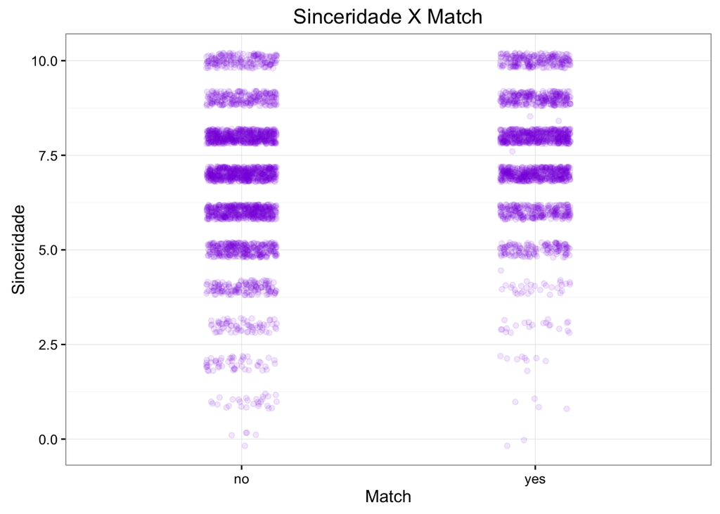

```r
ggplot(dados, aes(dados$dec, dados$sinc)) +
  geom_point(alpha = 0.1, position = position_jitter(width = 0.3), color="blueviolet") +
    labs(title="Sinceridade X Match", x= "Match", y="Sinceridade")
```

```r
bm <- glm(dec ~ sinc,
          data = dados,
          family = "binomial")
tidy(bm, conf.int = TRUE, exponentiate = TRUE)
```

```
##          term estimate  std.error statistic      p.value   conf.low
## 1 (Intercept) 0.126516 0.13224763 -15.63269 4.359824e-55 0.09741363
## 2        sinc 1.281262 0.01788013  13.86150 1.083927e-43 1.23744210
##   conf.high
## 1 0.1636057
## 2 1.3273007
```

Há correlação positiva nessa variável, porém ela é baixa.

### Construindo um modelo mais completo

```r
modelo <- glm(dec ~ attr + fun + like + prob  + sinc + shar, data=dados, family = 'binomial')
tidy(modelo, conf.int = TRUE, exponentiate = TRUE)
```

```
##          term    estimate  std.error  statistic       p.value     conf.low
## 1 (Intercept) 0.001354622 0.25283240 -26.120990 2.105837e-150 0.0008187922
## 2        attr 1.541766966 0.03046307  14.211606  7.762445e-46 1.4530310699
## 3         fun 1.069859481 0.03134354   2.154425  3.120686e-02 1.0061256562
## 4        like 1.805016476 0.04195855  14.075076  5.404711e-45 1.6637999406
## 5        prob 1.180820853 0.02231472   7.448438  9.445195e-14 1.1304232698
## 6        sinc 0.745077171 0.03002783  -9.799826  1.127799e-22 0.7021807764
## 7        shar 1.132592070 0.02571736   4.841434  1.289056e-06 1.0770094411
##     conf.high
## 1 0.002206405
## 2 1.637391267
## 3 1.137700275
## 4 1.961352539
## 5 1.233789428
## 6 0.789923482
## 7 1.191285546
```

No modelo vemos que a única variável que tem efeito negativo é a sinceridade ConfInterval<1. As demais tem efeito positivo, dentre elas as que mais se destacam são Atração e Gostar. As demais não tem efeito muito alto.